# Association rules

Movie recommender systems

مهسا خوش نما 93101481

2018-06-13 19:07:37

[figure not shown]

> با استفاده از داده نظرهای فیلم به سوالات زیر پاسخ دهید.

```r
library(readr)
library(stringr)
library(tidyr)
library(highcharter)
library(Hmisc)
library(dplyr)
library(corrplot)
library(car)
library(tidytext)
library(wordcloud)
library(tm)
library(colorspace)
library(knitr)
library(kableExtra)

movie = read_delim("F:/University/8th Semester/Data Analysis/Class/Week 12/ml-10m/ml-10M100K/movies.dat",
                   delim = "::",col_names = c("MovieID",NA,"Title",NA,"Genres"))
movie = movie %>% select(1,3,5)

rating = read_delim("F:/University/8th Semester/Data Analysis/Class/Week 12/ml-10m/ml-10M100K/ratings.dat",
                    delim = "::",col_names = c("UserID",NA,"MovieID",NA,"Rating",NA,"Timestamp"))
rating = rating %>% select(1,3,5,7)
```

۱. آماره های زیر را بیابید. الف. محبوب ترین فیلم کدام است؟ ب. بیشترین نظرات درباره چه فیلمی داده شده است؟ پ. منفورترین فیلم کدام است؟ ت. تعداد فیلم های ساخته شده در هر سال ث. در هر سالی مردم به چه ژانری علاقه مند بوده اند.

### پاسخ:

ده فیلم برتر به ترتیب محبوبیت: (در این قسمت علاوه بر فاکتور میانگین امتیاز، مقدار مینیمم 10000 نظر ثبت شده برای فیلم هم در نظر گرفته شده است.)

```r
##Part A:
movie %>% mutate(Year = str_extract(Title,"\\d{4}")) -> movie
rating %>% group_by(MovieID) %>% summarise(rate_count = n(),rate = mean(Rating)) %>%
  merge(movie) -> movie

movie %>% filter(rate_count>=10000) %>% arrange(-rate) %>% slice(1:10) -> best_movies
kable(best_movies)
```

| MovieID | rate_count | rate | Title | Genres | Year |
| --- | --- | --- | --- | --- | --- |
| 318 | 31126 | 4.457238 | Shawshank Redemption, The (1994) | Drama | 1994 |
| 858 | 19814 | 4.415085 | Godfather, The (1972) | Crime\|Drama | 1972 |
| 50 | 24037 | 4.367142 | Usual Suspects, The (1995) | Crime\|Mystery\|Thriller | 1995 |
| 527 | 25777 | 4.363483 | Schindler’s List (1993) | Drama\|War | 1993 |
| 912 | 12507 | 4.319741 | Casablanca (1942) | Drama\|Romance | 1942 |
| 1221 | 13281 | 4.303215 | Godfather | NA | NA |
| 750 | 11774 | 4.298072 | Dr. Strangelove or | NA | NA |
| 1193 | 14435 | 4.292380 | One Flew Over the Cuckoo’s Nest (1975) | Comedy\|Drama | 1975 |
| 1198 | 21803 | 4.261317 | Raiders of the Lost Ark (Indiana Jones and the Raiders of the Lost Ark) (1981) | Action\|Adventure | 1981 |
| 260 | 28566 | 4.220209 | Star Wars | NA | NA |

ده فیلم اول به ترتیب تعداد نظرات:

```r
##Part B:
movie %>% arrange(-rate_count) %>% slice(1:10) -> most_rates
kable(most_rates)
```

| MovieID | rate_count | rate | Title | Genres | Year |
| --- | --- | --- | --- | --- | --- |
| 296 | 34864 | 4.157426 | Pulp Fiction (1994) | Comedy\|Crime\|Drama | 1994 |
| 356 | 34457 | 4.013582 | Forrest Gump (1994) | Comedy\|Drama\|Romance\|War | 1994 |
| 593 | 33668 | 4.204200 | Silence of the Lambs, The (1991) | Crime\|Horror\|Thriller | 1991 |
| 480 | 32631 | 3.661564 | Jurassic Park (1993) | Action\|Adventure\|Sci-Fi\|Thriller | 1993 |
| 318 | 31126 | 4.457238 | Shawshank Redemption, The (1994) | Drama | 1994 |
| 110 | 29154 | 4.082390 | Braveheart (1995) | Action\|Drama\|War | 1995 |
| 457 | 28951 | 4.006926 | Fugitive, The (1993) | Thriller | 1993 |
| 589 | 28948 | 3.927698 | Terminator 2 | NA | NA |
| 260 | 28566 | 4.220209 | Star Wars | NA | NA |
| 150 | 27035 | 3.887350 | Apollo 13 (1995) | Adventure\|Drama | 1995 |

```r
##Part C:
movie %>% filter(rate_count>=1000) %>% arrange(rate) %>% slice(1:10) -> worst_movies
kable(worst_movies)
```

| MovieID | rate_count | rate | Title | Genres | Year |
| --- | --- | --- | --- | --- | --- |
| 3593 | 2072 | 1.577703 | Battlefield Earth (2000) | Action\|Sci-Fi | 2000 |
| 3268 | 1066 | 1.694653 | Stop! Or My Mom Will Shoot (1992) | Action\|Comedy | 1992 |
| 2383 | 1218 | 1.727833 | Police Academy 6 | NA | NA |
| 1760 | 1438 | 1.744089 | Spice World (1997) | Comedy\|Musical | 1997 |
| 2382 | 1240 | 1.782258 | Police Academy 5 | Miami Beach (1988) | NA |
| 1389 | 1159 | 1.798102 | Jaws 3-D (1983) | Action\|Horror | 1983 |
| 1707 | 1378 | 1.812409 | Home Alone 3 (1997) | Children\|Comedy | 1997 |
| 810 | 1067 | 1.841612 | Kazaam (1996) | Children\|Comedy\|Fantasy | 1996 |
| 1556 | 2851 | 1.865486 | Speed 2 | NA | NA |
| 393 | 1060 | 1.871226 | Street Fighter (1994) | Action\|Adventure\|Fantasy | 1994 |

ده سال اول به ترتیب تعداد فیلم ساخته شده:

```r
##Part D:
movie %>% group_by(Year) %>% summarize(num_movies = n()) %>% filter(!is.na(Year))-> num_movies
kable(num_movies %>% arrange(-num_movies) %>% head(10))
```

| Year | num_movies |
| --- | --- |
| 2002 | 415 |
| 2000 | 388 |
| 2001 | 384 |
| 1996 | 359 |
| 1998 | 358 |
| 1997 | 350 |
| 1995 | 342 |
| 1999 | 337 |
| 2003 | 336 |
| 2004 | 302 |

```r
#Part E:
genres = str_split(movie$Genres,"\\|") %>% unlist() %>% unique()
genres = genres[1:20]
genres = genres[!is.na(genres)]

rating = rating %>% mutate(Year = movie$Year[match(MovieID,movie$MovieID)],
                           Genres= movie$Genres[match(MovieID,movie$MovieID)])


for (i in 1:length(genres)){
  rating %>% mutate(genre = str_detect(Genres,genres[[i]])) -> rating
  colnames(rating)[6+i] = genres[i]
}

Genre_ratings = data.frame(Year = c(),genre = c(),mean_rate = c())
rating %>% filter(!is.na(Genres)) %>% filter(!is.na(Year))-> rating_genres
for (i in 1:length(genres)){
  count = rating_genres[rating_genres[,genres[i]]==T,] %>% group_by(Year) %>%
    summarise(mean_rate=mean(Rating)) %>% mutate(genre = genres[i]) %>% select(Year,genre,mean_rate)
  Genre_ratings = rbind(Genre_ratings,count)
}


Genre_ratings %>% filter(Year>=1900 & Year<=2010) %>% arrange(desc(mean_rate)) %>% group_by(Year) %>%
  top_n(1) -> Genre_ratings
Genre_ratings %>% arrange(desc(Year)) -> Genre_ratings

Genre_ratings
```

```
## # A tibble: 100 x 3
## # Groups:   Year [94]
##    Year  genre       mean_rate
##    <chr> <chr>           <dbl>
##  1 2007  Animation        3.91
##  2 2006  War              3.78
##  3 2005  Film-Noir        3.90
##  4 2004  Animation        3.75
##  5 2003  Documentary      3.80
##  6 2002  Documentary      3.84
##  7 2001  Animation        3.90
##  8 2000  Mystery          3.98
##  9 1999  Musical          3.98
## 10 1998  IMAX             3.93
## # ... with 90 more rows
```

```r
kable(Genre_ratings) %>%  kable_styling() %>%
  scroll_box(width = "900px", height = "600px")
```

| Year | genre | mean_rate |
| --- | --- | --- |
| 2007 | Animation | 3.912626 |
| 2006 | War | 3.783469 |
| 2005 | Film-Noir | 3.896361 |
| 2004 | Animation | 3.749111 |
| 2003 | Documentary | 3.797888 |
| 2002 | Documentary | 3.836384 |
| 2001 | Animation | 3.903294 |
| 2000 | Mystery | 3.983873 |
| 1999 | Musical | 3.984449 |
| 1998 | IMAX | 3.927242 |
| 1997 | Film-Noir | 3.999033 |
| 1996 | Documentary | 3.844380 |
| 1995 | War | 3.811385 |
| 1994 | Documentary | 4.004794 |
| 1993 | War | 3.977103 |
| 1992 | Documentary | 3.882162 |
| 1991 | Horror | 4.038010 |
| 1990 | Film-Noir | 3.851084 |
| 1989 | Western | 4.307692 |
| 1988 | Documentary | 4.106956 |
| 1987 | Film-Noir | 4.005540 |
| 1986 | Thriller | 3.734794 |
| 1985 | War | 4.146301 |
| 1984 | Documentary | 4.126551 |
| 1983 | Children | 4.007440 |
| 1982 | Film-Noir | 4.150258 |
| 1981 | War | 3.975768 |
| 1980 | Thriller | 3.864966 |
| 1979 | War | 4.092522 |
| 1978 | War | 3.904316 |

[output cut: 70 more lines]

۲. ژانر فیلم ها را استخراج نمایید. سپس آماره های زیر را استخراج نمایید. الف. نمودار ستونی تعداد فیلم های هر ژانر ب. نمودار همبستگی ژانرها پ. متوسط امتیاز به هر ژانر ت. دوران طلایی فیلم سازی

### پاسخ:

```r
##Part A:
for (i in 1:length(genres)){
  movie %>% mutate(genre = str_detect(Genres,genres[[i]])) -> movie
  colnames(movie)[6+i] = genres[i]
}
movie_genres = movie %>% filter(!is.na(Genres))

genre_counts = data.frame(genre=c(),count=c())
for (i in 1:length(genres)){
  count = movie_genres[movie_genres[,genres[i]]==T,] %>% nrow()
  genre_counts = rbind(genre_counts,data.frame(genre=c(genres[i]),count= c(count)))
}

genre_counts %>% arrange(-count) -> genre_counts
hchart(genre_counts,type = 'column',hcaes(x = genre,y=count,color = -count), name='number of t') %>%
  hc_add_theme(hc_theme_google()) %>% hc_title(text="Number of Movies of Each Genre")
```

[interactive chart not shown]

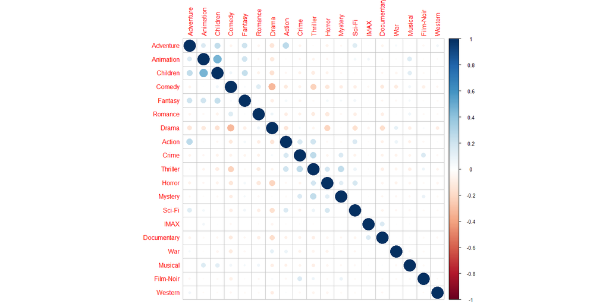

```r
##Part B:
library(car)
for (i in 1:length(genres)){
  movie_genres[,genres[[i]]] = recode(movie_genres[,genres[[i]]],"TRUE=1;FALSE=0")
}
stat = movie_genres[,7:ncol(movie_genres)]
corr = rcorr(as.matrix(stat))
corr_matrix = corr[[1]]
corrplot(corr_matrix)
```

```r
##Part C:
Genre_ratings = data.frame(genre = c(),mean_rate = c())
for (i in 1:length(genres)){
  count = rating_genres[rating_genres[,genres[i]]==T,]
  Genre_ratings = rbind(Genre_ratings,data.frame(genre = c(genres[[i]]),mean_rate = mean(count$Rating)))
}

Genre_ratings %>% arrange(-mean_rate) -> Genre_ratings
kable(Genre_ratings) %>%  kable_styling() %>%
  scroll_box(width = "900px", height = "600px")
```

| genre | mean_rate |
| --- | --- |
| Film-Noir | 4.013971 |
| Documentary | 3.798001 |
| War | 3.781694 |
| Mystery | 3.697093 |
| Drama | 3.676585 |
| Crime | 3.659698 |
| Western | 3.590057 |
| Animation | 3.588848 |
| Musical | 3.564170 |
| Romance | 3.554572 |
| IMAX | 3.542907 |
| Thriller | 3.518491 |
| Fantasy | 3.483743 |
| Adventure | 3.471696 |
| Comedy | 3.449312 |
| Children | 3.432197 |
| Action | 3.399940 |
| Sci-Fi | 3.349897 |
| Horror | 3.320351 |

```r
##Part D:
rating %>% filter(!is.na(Year)) %>% group_by(Year) %>% summarise(mean_rate = mean(Rating)) %>%
  arrange(-mean_rate) %>% head(10) -> Year_Ratings
kable(Year_Ratings)
```

| Year | mean_rate |
| --- | --- |
| 1946 | 4.056434 |
| 1934 | 4.052488 |
| 1942 | 4.043891 |
| 1931 | 4.026543 |
| 1927 | 4.016114 |
| 1957 | 4.011842 |
| 1954 | 4.011391 |
| 1941 | 3.999721 |
| 1944 | 3.991432 |
| 1962 | 3.986258 |

۳. نمودار ابر لغات را بر حسب کلمات عنوان فیلم ها رسم نمایید.

### پاسخ:

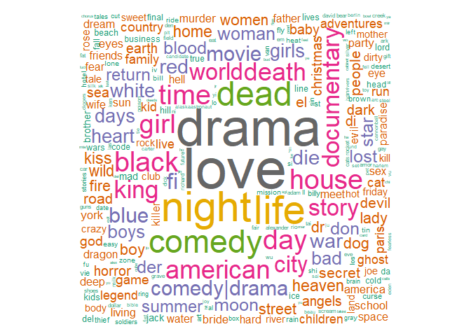

```r
words = data.frame(word = movie$Title %>% str_replace_all("[:punct:]"," ") %>%
                     str_replace_all("[:digit:]"," ") %>% str_split("\\s+") %>% unlist(),
                   stringsAsFactors = F)
words  %>%  filter(!str_to_lower(word) %in% stop_words$word) %>%
  filter(!(str_to_lower(word) %in% stopwords('fr'))) %>%
  filter(str_length(word)>1) %>% mutate(word2 = str_to_lower(word)) %>%
  filter(!(word2 %in% c("i","ii","iii"))) %>%
  group_by(word2) %>% summarise(count = n()) %>% arrange(-count) -> words

wordcloud(words$word2,words$count,size=0.1,
          c(5,.3), random.order = FALSE, colors=brewer.pal(8, "Dark2"))
```

۴. با استفاده از قوانین همبستگی یک توصیه گر برای فیلم ها بسازید. شبیه ترین فیلم ها به لیست زیر را پیدا کنید.

- Castle in the Sky (1986)
- Cast Away (2000)
- No Country for Old Men (2007)
- Memento (2000)

### پاسخ:

```r
setwd("F:/University/8th Semester/Data Analysis/HWs/hw_12")
library(arules)

df_rating = rating %>% filter(Rating>=3) %>%  select(UserID,MovieID)
df_rating = df_rating %>% mutate(title = paste("movie",as.character(MovieID),
                                               movie$Title[match(MovieID,movie$MovieID)]))

df_rating = df_rating %>% select(UserID,title)
write.csv(df_rating, "transactions.csv")

transactions <- read.transactions(
  file = "transactions.csv",
  format = "single",
  sep = ",",
  cols=c("UserID","title"),
  rm.duplicates = T
)

ID1 = paste("movie",as.character(movie$MovieID[str_detect(movie$Title,"Castle in the Sky")]),
            movie$Title[str_detect(movie$Title,"Castle in the Sky")])
ID2 = paste("movie",as.character(movie$MovieID[str_detect(movie$Title,"Cast Away")]),
            movie$Title[str_detect(movie$Title,"Cast Away")])
ID3 = paste("movie",as.character(movie$MovieID[str_detect(movie$Title,"No Country for Old Men")]),
            movie$Title[str_detect(movie$Title,"No Country for Old Men")])
ID4 = paste("movie",as.character(movie$MovieID[str_detect(movie$Title,"Memento")]),
            movie$Title[str_detect(movie$Title,"Memento")])

rules <- apriori(transactions,parameter = list(support = 0.009,confidence = 0.25,maxtime = 0,
                                               minlen = 5,maxlen=5),
                 appearance = list(lhs=c(ID1,ID2,ID3,ID4),
                                   default="rhs"))
```

```
## Apriori
##
## Parameter specification:
##  confidence minval smax arem  aval originalSupport maxtime support minlen
##        0.25    0.1    1 none FALSE            TRUE       0   0.009      5
##  maxlen target   ext
##       5  rules FALSE
##
## Algorithmic control:
##  filter tree heap memopt load sort verbose
##     0.1 TRUE TRUE  FALSE TRUE    2    TRUE
##
## Absolute minimum support count: 628
##
## set item appearances ...[4 item(s)] done [0.00s].
## set transactions ...[10598 item(s), 69863 transaction(s)] done [1.07s].
## sorting and recoding items ... [2264 item(s)] done [0.25s].
## creating transaction tree ... done [0.07s].
## checking subsets of size 1 2 3 done [1.06s].
## writing ... [0 rule(s)] done [0.00s].
## creating S4 object  ... done [0.04s].
```

```r
inspect(rules)
```

مشاهده می شود که با پارامترهای فوق هیچ فیلمی پیشنهاد نمی شود. با تغییر پارامترهای فوق و کم کردن آن ها هم تغیری مشاهده نمی شود. یکی از دلایل این مساله می تواند تعداد کم کاربرانی باشد که فیلم سوم در لیست فیلم های آن هاست. (فقط 6کاربر). حال به جای لیست فوق به صورت کامل، زیرمجموعه های 3 عضوی و دوعضوی آن را بررسی می کنیم و می بینیم برای آن ها چه قواعدی وجود دارد.

```r
rules <- apriori(transactions,parameter = list(support = 0.009,confidence = 0.25,maxtime = 0,
                                               minlen = 4,maxlen=4),
                 appearance = list(lhs=c(ID1,ID2,ID3),
                                   default="rhs"))
```

```
## Apriori
##
## Parameter specification:
##  confidence minval smax arem  aval originalSupport maxtime support minlen
##        0.25    0.1    1 none FALSE            TRUE       0   0.009      4
##  maxlen target   ext
##       4  rules FALSE
##
## Algorithmic control:
##  filter tree heap memopt load sort verbose
##     0.1 TRUE TRUE  FALSE TRUE    2    TRUE
##
## Absolute minimum support count: 628
##
## set item appearances ...[3 item(s)] done [0.00s].
## set transactions ...[10598 item(s), 69863 transaction(s)] done [1.11s].
## sorting and recoding items ... [2264 item(s)] done [0.24s].
## creating transaction tree ... done [0.07s].
## checking subsets of size 1 2 done [0.39s].
## writing ... [0 rule(s)] done [0.00s].
## creating S4 object  ... done [0.02s].
```

```r
inspect(rules)
```

```r
rules <- apriori(transactions,parameter = list(support = 0.009,confidence = 0.25,maxtime = 0,
                                               minlen = 4,maxlen=4),
                 appearance = list(lhs=c(ID1,ID2,ID4),
                                   default="rhs"))
```

```
## Apriori
##
## Parameter specification:
##  confidence minval smax arem  aval originalSupport maxtime support minlen
##        0.25    0.1    1 none FALSE            TRUE       0   0.009      4
##  maxlen target   ext
##       4  rules FALSE
##
## Algorithmic control:
##  filter tree heap memopt load sort verbose
##     0.1 TRUE TRUE  FALSE TRUE    2    TRUE
##
## Absolute minimum support count: 628
##
## set item appearances ...[3 item(s)] done [0.00s].
## set transactions ...[10598 item(s), 69863 transaction(s)] done [1.07s].
## sorting and recoding items ... [2264 item(s)] done [0.24s].
## creating transaction tree ... done [0.06s].
## checking subsets of size 1 2 3 done [1.02s].
## writing ... [0 rule(s)] done [0.00s].
## creating S4 object  ... done [0.02s].
```

```r
inspect(rules)
```

```r
rules <- apriori(transactions,parameter = list(support = 0.009,confidence = 0.25,maxtime = 0,
                                               minlen = 4,maxlen=4),
                 appearance = list(lhs=c(ID1,ID3,ID4),
                                   default="rhs"))
```

```
## Apriori
##
## Parameter specification:
##  confidence minval smax arem  aval originalSupport maxtime support minlen
##        0.25    0.1    1 none FALSE            TRUE       0   0.009      4
##  maxlen target   ext
##       4  rules FALSE
##
## Algorithmic control:
##  filter tree heap memopt load sort verbose
##     0.1 TRUE TRUE  FALSE TRUE    2    TRUE
##
## Absolute minimum support count: 628
##
## set item appearances ...[3 item(s)] done [0.00s].
## set transactions ...[10598 item(s), 69863 transaction(s)] done [1.15s].
## sorting and recoding items ... [2264 item(s)] done [0.25s].
## creating transaction tree ... done [0.06s].
## checking subsets of size 1 2 3 done [0.72s].
## writing ... [0 rule(s)] done [0.00s].
## creating S4 object  ... done [0.02s].
```

```r
inspect(rules)
```

```r
rules <- apriori(transactions,parameter = list(support = 0.009,confidence = 0.25,maxtime = 0,
                                               minlen = 4,maxlen=4),
                 appearance = list(lhs=c(ID2,ID3,ID4),
                                   default="rhs"))
```

```
## Apriori
##
## Parameter specification:
##  confidence minval smax arem  aval originalSupport maxtime support minlen
##        0.25    0.1    1 none FALSE            TRUE       0   0.009      4
##  maxlen target   ext
##       4  rules FALSE
##
## Algorithmic control:
##  filter tree heap memopt load sort verbose
##     0.1 TRUE TRUE  FALSE TRUE    2    TRUE
##
## Absolute minimum support count: 628
##
## set item appearances ...[3 item(s)] done [0.00s].
## set transactions ...[10598 item(s), 69863 transaction(s)] done [1.03s].
## sorting and recoding items ... [2264 item(s)] done [0.24s].
## creating transaction tree ... done [0.06s].
## checking subsets of size 1 2 3 done [0.92s].
## writing ... [0 rule(s)] done [0.00s].
## creating S4 object  ... done [0.02s].
```

```r
inspect(rules)
```

```r
rules <- apriori(transactions,parameter = list(support = 0.009,confidence = 0.25,maxtime = 0,
                                               minlen = 3,maxlen=3),
                 appearance = list(lhs=c(ID1,ID2),
                                   default="rhs"))
```

```
## Apriori
##
## Parameter specification:
##  confidence minval smax arem  aval originalSupport maxtime support minlen
##        0.25    0.1    1 none FALSE            TRUE       0   0.009      3
##  maxlen target   ext
##       3  rules FALSE
##
## Algorithmic control:
##  filter tree heap memopt load sort verbose
##     0.1 TRUE TRUE  FALSE TRUE    2    TRUE
##
## Absolute minimum support count: 628
##
## set item appearances ...[2 item(s)] done [0.00s].
## set transactions ...[10598 item(s), 69863 transaction(s)] done [1.06s].
## sorting and recoding items ... [2264 item(s)] done [0.24s].
## creating transaction tree ... done [0.06s].
## checking subsets of size 1 2 done [0.39s].
## writing ... [0 rule(s)] done [0.00s].
## creating S4 object  ... done [0.02s].
```

```r
inspect(rules)
```

```r
rules <- apriori(transactions,parameter = list(support = 0.009,confidence = 0.25,maxtime = 0,
                                               minlen = 3,maxlen=3),
                 appearance = list(lhs=c(ID1,ID3),
                                   default="rhs"))
```

```
## Apriori
##
## Parameter specification:
##  confidence minval smax arem  aval originalSupport maxtime support minlen
##        0.25    0.1    1 none FALSE            TRUE       0   0.009      3
##  maxlen target   ext
##       3  rules FALSE
##
## Algorithmic control:
##  filter tree heap memopt load sort verbose
##     0.1 TRUE TRUE  FALSE TRUE    2    TRUE
##
## Absolute minimum support count: 628
##
## set item appearances ...[2 item(s)] done [0.00s].
## set transactions ...[10598 item(s), 69863 transaction(s)] done [1.03s].
## sorting and recoding items ... [2264 item(s)] done [0.24s].
## creating transaction tree ... done [0.06s].
## checking subsets of size 1 2 done [0.02s].
## writing ... [0 rule(s)] done [0.00s].
## creating S4 object  ... done [0.02s].
```

```r
inspect(rules)
```

```r
rules <- apriori(transactions,parameter = list(support = 0.009,confidence = 0.25,maxtime = 0,
                                               minlen = 3,maxlen=3),
                 appearance = list(lhs=c(ID1,ID4),
                                   default="rhs"))
```

```
## Apriori
##
## Parameter specification:
##  confidence minval smax arem  aval originalSupport maxtime support minlen
##        0.25    0.1    1 none FALSE            TRUE       0   0.009      3
##  maxlen target   ext
##       3  rules FALSE
##
## Algorithmic control:
##  filter tree heap memopt load sort verbose
##     0.1 TRUE TRUE  FALSE TRUE    2    TRUE
##
## Absolute minimum support count: 628
##
## set item appearances ...[2 item(s)] done [0.00s].
## set transactions ...[10598 item(s), 69863 transaction(s)] done [1.02s].
## sorting and recoding items ... [2264 item(s)] done [0.24s].
## creating transaction tree ... done [0.06s].
## checking subsets of size 1 2 3 done [0.63s].
## writing ... [7 rule(s)] done [0.00s].
## creating S4 object  ... done [0.02s].
```

```r
inspect(rules)
```

```
##     lhs                                                               rhs                                                                   support confidence      lift count
## [1] {movie 4226 Memento (2000),
##      movie 6350 Castle in the Sky (Tenkû no shiro Rapyuta) (1986)} => {movie 5618 Spirited Away (Sen to Chihiro no kamikakushi) (2001)} 0.009990982  0.9064935 13.854814   698
## [2] {movie 4226 Memento (2000),
##      movie 6350 Castle in the Sky (Tenkû no shiro Rapyuta) (1986)} => {movie 7153 Lord of the Rings}                                    0.009246668  0.8389610  5.114961   646
## [3] {movie 4226 Memento (2000),
##      movie 6350 Castle in the Sky (Tenkû no shiro Rapyuta) (1986)} => {movie 5952 Lord of the Rings}                                    0.009275296  0.8415584  4.418261   648
## [4] {movie 4226 Memento (2000),
##      movie 6350 Castle in the Sky (Tenkû no shiro Rapyuta) (1986)} => {movie 2959 Fight Club (1999)}                                    0.009232355  0.8376623  3.840756   645
## [5] {movie 4226 Memento (2000),
##      movie 6350 Castle in the Sky (Tenkû no shiro Rapyuta) (1986)} => {movie 4993 Lord of the Rings}                                    0.009804904  0.8896104  4.212475   685
## [6] {movie 4226 Memento (2000),
##      movie 6350 Castle in the Sky (Tenkû no shiro Rapyuta) (1986)} => {movie 2571 Matrix, The (1999)}                                   0.009962355  0.9038961  2.896871   696
## [7] {movie 4226 Memento (2000),
##      movie 6350 Castle in the Sky (Tenkû no shiro Rapyuta) (1986)} => {movie 296 Pulp Fiction (1994)}                                   0.009103531  0.8259740  1.784434   636
```

```r
rules <- apriori(transactions,parameter = list(support = 0.009,confidence = 0.25,maxtime = 0,
                                               minlen = 3,maxlen=3),
                 appearance = list(lhs=c(ID2,ID3),
                                   default="rhs"))
```

```
## Apriori
##
## Parameter specification:
##  confidence minval smax arem  aval originalSupport maxtime support minlen
##        0.25    0.1    1 none FALSE            TRUE       0   0.009      3
##  maxlen target   ext
##       3  rules FALSE
##
## Algorithmic control:
##  filter tree heap memopt load sort verbose
##     0.1 TRUE TRUE  FALSE TRUE    2    TRUE
##
## Absolute minimum support count: 628
##
## set item appearances ...[2 item(s)] done [0.00s].
## set transactions ...[10598 item(s), 69863 transaction(s)] done [1.04s].
## sorting and recoding items ... [2264 item(s)] done [0.24s].
## creating transaction tree ... done [0.06s].
## checking subsets of size 1 2 done [0.31s].
## writing ... [0 rule(s)] done [0.00s].
## creating S4 object  ... done [0.02s].
```

```r
inspect(rules)
```

```r
rules <- apriori(transactions,parameter = list(support = 0.009,confidence = 0.25,maxtime = 0,
                                               minlen = 3,maxlen=3),
                 appearance = list(lhs=c(ID2,ID4),
                                   default="rhs"))
```

```
## Apriori
##
## Parameter specification:
##  confidence minval smax arem  aval originalSupport maxtime support minlen
##        0.25    0.1    1 none FALSE            TRUE       0   0.009      3
##  maxlen target   ext
##       3  rules FALSE
##
## Algorithmic control:
##  filter tree heap memopt load sort verbose
##     0.1 TRUE TRUE  FALSE TRUE    2    TRUE
##
## Absolute minimum support count: 628
##
## set item appearances ...[2 item(s)] done [0.00s].
## set transactions ...[10598 item(s), 69863 transaction(s)] done [1.04s].
## sorting and recoding items ... [2264 item(s)] done [0.24s].
## creating transaction tree ... done [0.06s].
## checking subsets of size 1 2 3 done [0.90s].
## writing ... [384 rule(s)] done [0.00s].
## creating S4 object  ... done [0.02s].
```

```r
inspect(rules)
```

```
##       lhs                              rhs                                                                                                            support confidence     lift count
## [1]   {movie 4022 Cast Away (2000),
##        movie 4226 Memento (2000)}   => {movie 4874 K-PAX (2001)}                                                                                   0.01607432  0.2611021 7.078531  1123
## [2]   {movie 4022 Cast Away (2000),
##        movie 4226 Memento (2000)}   => {movie 4019 Finding Forrester (2000)}                                                                       0.01557334  0.2529644 6.511737  1088
## [3]   {movie 4022 Cast Away (2000),
##        movie 4226 Memento (2000)}   => {movie 46578 Little Miss Sunshine (2006)}                                                                   0.01651804  0.2683097 5.617297  1154
## [4]   {movie 4022 Cast Away (2000),
##        movie 4226 Memento (2000)}   => {movie 4239 Blow (2001)}                                                                                    0.01714785  0.2785399 6.728780  1198
## [5]   {movie 4022 Cast Away (2000),
##        movie 4226 Memento (2000)}   => {movie 6373 Bruce Almighty (2003)}                                                                          0.01584530  0.2573820 6.237072  1107
## [6]   {movie 4022 Cast Away (2000),
##        movie 4226 Memento (2000)}   => {movie 6942 Love Actually (2003)}                                                                           0.01553040  0.2522669 5.563170  1085
## [7]   {movie 4022 Cast Away (2000),
##        movie 4226 Memento (2000)}   => {movie 8644 I, Robot (2004)}                                                                                0.01587392  0.2578470 5.677266  1109
## [8]   {movie 4022 Cast Away (2000),
##        movie 4226 Memento (2000)}   => {movie 3916 Remember the Titans (2000)}                                                                     0.01570216  0.2550570 5.346248  1097
## [9]   {movie 4022 Cast Away (2000),
##        movie 4226 Memento (2000)}   => {movie 6934 Matrix Revolutions, The (2003)}                                                                 0.01687589  0.2741223 5.428290  1179
## [10]  {movie 4022 Cast Away (2000),
##        movie 4226 Memento (2000)}   => {movie 5956 Gangs of New York (2002)}                                                                       0.01713353  0.2783074 7.182633  1197
## [11]  {movie 4022 Cast Away (2000),
##        movie 4226 Memento (2000)}   => {movie 49272 Casino Royale (2006)}                                                                          0.01716216  0.2787724 5.354928  1199
## [12]  {movie 4022 Cast Away (2000),
##        movie 4226 Memento (2000)}   => {movie 33166 Crash (2004)}                                                                                  0.01866510  0.3031853 6.381873  1304
## [13]  {movie 4022 Cast Away (2000),
##        movie 4226 Memento (2000)}   => {movie 4975 Vanilla Sky (2001)}                                                                             0.01963844  0.3189956 7.177452  1372
## [14]  {movie 4022 Cast Away (2000),
##        movie 4226 Memento (2000)}   => {movie 5266 Panic Room (2002)}                                                                              0.01822138  0.2959777 7.641496  1273
## [15]  {movie 4022 Cast Away (2000),
##        movie 4226 Memento (2000)}   => {movie 4223 Enemy at the Gates (2001)}                                                                      0.01804961  0.2931876 6.490167  1261
## [16]  {movie 4022 Cast Away (2000),
##        movie 4226 Memento (2000)}   => {movie 48516 Departed, The (2006)}                                                                          0.01845040  0.2996977 5.292665  1289
## [17]  {movie 4022 Cast Away (2000),
##        movie 4226 Memento (2000)}   => {movie 6016 City of God (Cidade de Deus) (2002)}                                                            0.01714785  0.2785399 4.601473  1198
## [18]  {movie 4022 Cast Away (2000),
##        movie 4226 Memento (2000)}   => {movie 3967 Billy Elliot (2000)}                                                                            0.01687589  0.2741223 5.585012  1179
## [19]  {movie 4022 Cast Away (2000),
##        movie 4226 Memento (2000)}   => {movie 44191 V for Vendetta (2006)}                                                                         0.01847902  0.3001628 5.251758  1291
## [20]  {movie 4022 Cast Away (2000),
```

[output cut: 714 more lines]

```
##        movie 4226 Memento (2000)}   => {movie 1196 Star Wars}                                                                                      0.04434393  0.7202976 2.289244  3098
## [378] {movie 4022 Cast Away (2000),
##        movie 4226 Memento (2000)}   => {movie 589 Terminator 2}                                                                                    0.04208236  0.6835620 1.765460  2940
## [379] {movie 4022 Cast Away (2000),
##        movie 4226 Memento (2000)}   => {movie 480 Jurassic Park (1993)}                                                                            0.04453001  0.7233202 1.735705  3111
## [380] {movie 4022 Cast Away (2000),
##        movie 4226 Memento (2000)}   => {movie 260 Star Wars}                                                                                       0.04451570  0.7230877 1.867959  3110
## [381] {movie 4022 Cast Away (2000),
##        movie 4226 Memento (2000)}   => {movie 318 Shawshank Redemption, The (1994)}                                                                0.04958275  0.8053941 1.841025  3464
## [382] {movie 4022 Cast Away (2000),
##        movie 4226 Memento (2000)}   => {movie 356 Forrest Gump (1994)}                                                                             0.04905315  0.7967914 1.747214  3427
## [383] {movie 4022 Cast Away (2000),
##        movie 4226 Memento (2000)}   => {movie 296 Pulp Fiction (1994)}                                                                             0.04879550  0.7926064 1.712346  3409
## [384] {movie 4022 Cast Away (2000),
##        movie 4226 Memento (2000)}   => {movie 593 Silence of the Lambs, The (1991)}                                                                0.04875256  0.7919089 1.708673  3406
```

۵. تمرین سخت: در گیت هاب برای خود اکانت درست کنید. همه تمرین های خود را آنجا بارگذاری کنید! و لینک آن را ارسال نمایید.

### پاسخ:

https://github.com/mahsa-khoshnama/Data-Analysis-Homeworks

۶. پنج انتقاد از درس و نحوه تدریس را بیان کنید.

### پاسخ:

روند پیشرفت درس یکنواخت نبود و در ابتدا سرعت درس کم بود ولی به تدریج بهتر شد.

به نظر بنده، ساعت کلاس برای این درس مناسب نبود و زود بود.

مباحث تئوری قوی مطرح نشدند و به تبع آن تحلیل های پیشرفته تر هم تدریس نشدند.

تمرین اول درس به نظر اصلا مرتبط بادرس نبود.

بعضی از تمارین مقدار زیادی ابهام داشتند.

۷. پنج پیشنهاد برای بهتر شدن درس بیان کنید.

بهتر است از ابتدا روند درس سریعتر باشد تا فرصت پوشش مطالب بیتشری فراهم شود.

برای این درس که تعداد متقاضی زیادی هم دارد به نظر ساعت 10ونیم تا 12ونیم مناسبتر است. همان طور که مشاهده می شد در اواخر ترم حضور در کلاس کاهش یافته بود و بنده حدس میزنم به دلیل مشغله های زیاد دانشجویان در اواخر ترم اکثرا تا دیروقت بیدار هستند و کلاس های اول صبح را حاضر نمی شوند.

مباحث تئوری قوی تر و تحلیل های پیشرفته تری تدریس شوند.

تمارین از ابتدا مرتبط با موضوع درس طرح شوند.

صورت سوالات تمارین واضح تر و شفاف تر باشند.

۸. سه موضوع آماری جدید برای جایگزینی در سرفصل ها پیشنهاد دهید.

سایر روش ها برای کاهش بعد داده ها و feature selection مانند SVD، backward/forward selection و …

سایر مدل های یادگیری ماشینی (علاوه بر رگرسیون خطی و لاجستیک) مانند SVM

سایر روش های clustering مانند spectral clustering

۹. سه داده جالب برای کار در کلاس پیشنهاد دهید.

داده های مصرف برق خانوارها، داده های سبد خرید مشتریان فروشگاه های بزرگ، داده های جرائم و خلاف ها (که تعداد زیادی از آن ها به صورت عمومی در بعضی ایالت های آمریکا منتشر می شوند مثلا جرائم ترافیکی و جریمه های آن ها)

۱۰. چهار نکته مهمی که در کلاس یاد گرفتید را بیان کنید.

تحلیل اکتشافی داده و گرفتن شهود نسبت به داده ها

به کارگیری آزمون فرض برای بررسی درستی مدل های به کار رفته

نحوه استخراج داده از صفحات وب